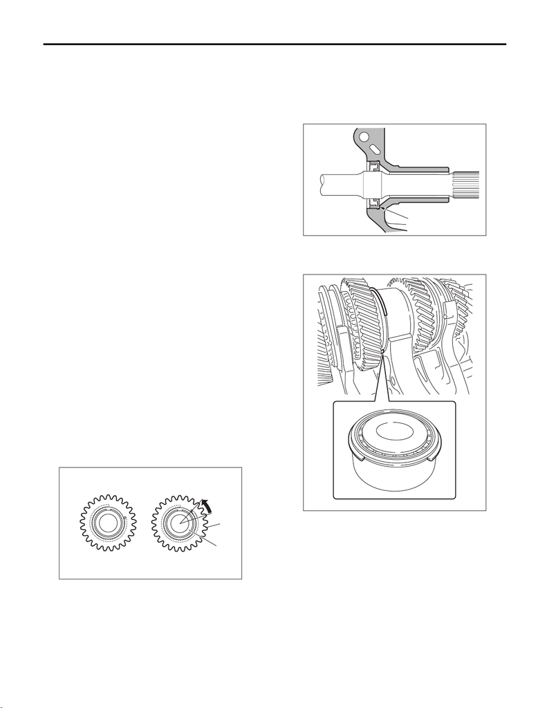

6MT(TY75)-83

Main Shaft Assembly for Single-Range

MANUAL TRANSMISSION AND DIFFERENTIAL

16.Main Shaft Assembly for Sin-

gle-Range

A: REMOVAL

1) Remove the manual transmission assembly

from the vehicle. <Ref. to 6MT(TY75)-25, REMOV-

AL, Manual Transmission Assembly.>

2) Remove the transfer case together with the ex-

tension case assembly. <Ref. to 6MT(TY75)-51,

REMOVAL, Transfer Case and Extension Case

Assembly.>

3) Remove the transmission case. <Ref. to

6MT(TY75)-79, REMOVAL, Transmission Case.>

4) Remove the drive pinion shaft assembly. <Ref.

to 6MT(TY75)-92, REMOVAL, Drive Pinion Shaft

Assembly.>

5) Remove the main shaft assembly.

B: INSTALLATION

1) Attach the needle bearing and oil seal to the

front of the main shaft assembly.

NOTE:

• Wrap the clutch splined section with vinyl tape to

prevent damage to the oil seal.

• Apply NICHIMOLY N-130 or the equivalent to

the sealing lip of the oil seal.

• Use a new oil seal.

2) Rotate the reverse idler sub gear by two teeth

from free status in the direction of the arrow to

make it engage with the reverse gear of the main

shaft and install the main shaft assembly.

(1) When the reverse idler sub gear is at free

status, put alignment marks on reverse idler

sub gear and reverse idler gear.

(2) Rotate the alignment mark on the reverse

idler sub gear side in the arrow direction by two

teeth, and secure it with a wire.

3) Fit the transmission case knock pin to the knock

pin hole of the needle bearing outer race and install

the main shaft assembly.

NOTE:

• Align the end face of the seal with surface (A)

when installing the oil seal.

• Face the cutout portion of the snap ring for the

double taper roller bearing to the drive pinion shaft

assembly.

4) After installing the main shaft, check that the re-

verse idler gear and reverse idler sub gear are mis-

aligned by two teeth and remove the wire.

5) Install the drive pinion shaft assembly. <Ref. to

6MT(TY75)-92, INSTALLATION, Drive Pinion

Shaft Assembly.>

6) Check each shifter fork. <Ref. to 6MT(TY75)-

140, INSPECTION, Shifter Fork and Rod.>

7) Select a main shaft rear plate. <Ref. to

6MT(TY75)-91, ADJUSTMENT, Main Shaft As-

sembly for Single-Range.>

8) Install the transmission case. <Ref. to

6MT(TY75)-80, INSTALLATION, Transmission

Case.>

(A) Free status

(B) Set status

(C) Reverse idler sub gear

(D) Reverse idler gear

MT-02684

(C)

(A)

(B)

(D)

MT-02748

(A)

MT-02472

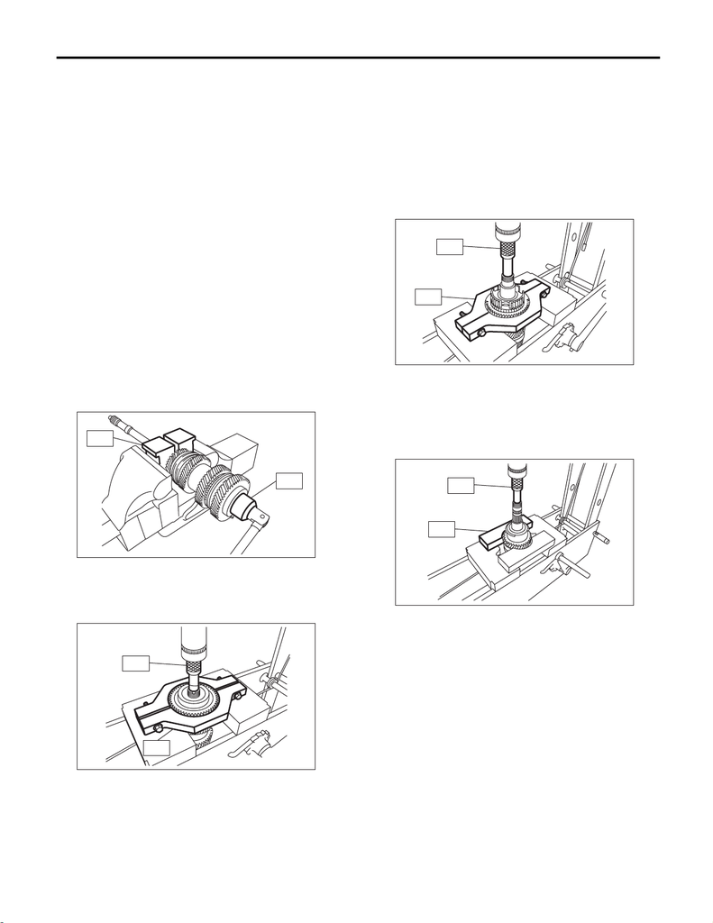

6MT(TY75)-84

Main Shaft Assembly for Single-Range

MANUAL TRANSMISSION AND DIFFERENTIAL

9) Install the transfer case together with the exten-

sion case assembly. <Ref. to 6MT(TY75)-53, IN-

STALLATION, Transfer Case and Extension Case

Assembly.>

10) Install the manual transmission assembly to the

vehicle. <Ref. to 6MT(TY75)-30, INSTALLATION,

Manual Transmission Assembly.>

C: DISASSEMBLY

NOTE:

When replacing the coupling sleeve and synchro-

nizer hub, replace them as a set. Because these

must engage at the specified point, avoid disas-

sembly as much as possible. If it is necessary to

disassemble, mark the engaging points on the

splines beforehand.

1) Put vinyl tape around the main shaft spline and

pull out the oil seal and needle bearing by hand to

prevent the oil seal from being damaged.

2) Flatten the tab of the lock nut.

3) Remove the lock nut and lock washer using ST1

and ST2.

ST1 498937000 TRANSMISSION HOLDER

ST2 499987003 SOCKET WRENCH (35)

4) Remove the 6th drive gear and ball bearing us-

ing the ST1, ST2 and a press.

ST1 899864100 REMOVER

ST2 18722AA010 REMOVER

5) Remove the needle bearing, 6th baulk ring, 5th-

6th shifting insert and 5th-6th coupling sleeve.

CAUTION:

When removing the 5th-6th coupling sleeve, be

careful not to lose the 5th-6th shifting insert.

6) Remove the 5th drive gear, 6th needle bearing

race, 5th baulk ring, 5th-6th synchronizer hub and

needle bearing using the ST1, ST2 and a press.

ST1 899864100 REMOVER

ST2 18722AA010 REMOVER

7) Shift the 3rd-4th coupling sleeve to the 3rd side.

8) Remove the 4th drive gear, 4th gear adjusting

washer, double taper roller bearing and 5th needle

bearing race using the ST1, ST2 and a press.

ST1 899864100 REMOVER

ST2 899714110 REMOVER

9) Remove the 4th baulk ring, needle bearing, 3rd-

4th shifting insert and 3rd-4th coupling sleeve.

CAUTION:

When removing the 3rd-4th coupling sleeve, be

careful not to lose the 3rd-4th shifting insert.

MT-02473

ST1

ST2

MT-02474

ST1

ST2

MT-02475

ST1

ST2

MT-02476

ST1

ST2

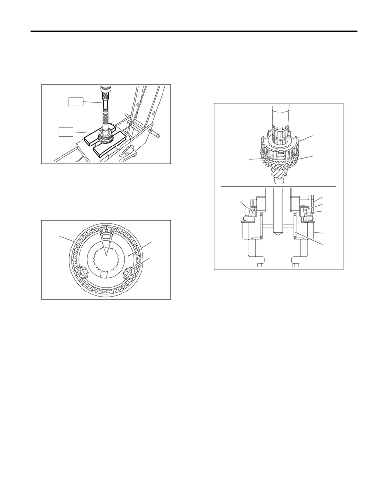

6MT(TY75)-85

Main Shaft Assembly for Single-Range

MANUAL TRANSMISSION AND DIFFERENTIAL

10) Remove the 3rd drive gear, 4th needle bearing

race, 3rd-4th synchronizer hub, 3rd inner baulk

ring, 3rd synchro cone, 3rd outer baulk ring and

needle bearing using the ST1, ST2 and a press.

ST1 899864100 REMOVER

ST2 899714110 REMOVER

D: ASSEMBLY

NOTE:

• Match the alignment marks, and install the cou-

pling sleeve and then install the shifting insert.

• Make sure that there is no large clearance at

both sides of the shifting insert after assembly.

1) Install the needle bearing, 3rd drive gear, 3rd

outer baulk ring, 3rd synchro cone, 3rd inner baulk

ring and 3rd-4th synchronizer hub.

NOTE:

• Install the 3rd-4th synchronizer hub in the correct

direction.

• Align the protrusion of the outer baulk ring into

the groove of the 3rd-4th synchronizer hub.

(A) Shifting insert

(B) Synchronizer hub

(C) Coupling sleeve

(D) There is no large clearance at this part.

MT-02477

ST1

ST2

MT-02541

(A)

(B)

(C)

(D)

(A) 3rd needle bearing

(B) 3rd drive gear

(C) 3rd inner baulk ring

(D) 3rd synchro cone

(E) 3rd outer baulk ring

(F) 3rd-4th synchronizer hub

MT-02478

(E)

(B)

(F)

(C)

(E)

(D)

(F)

(B)

(A)

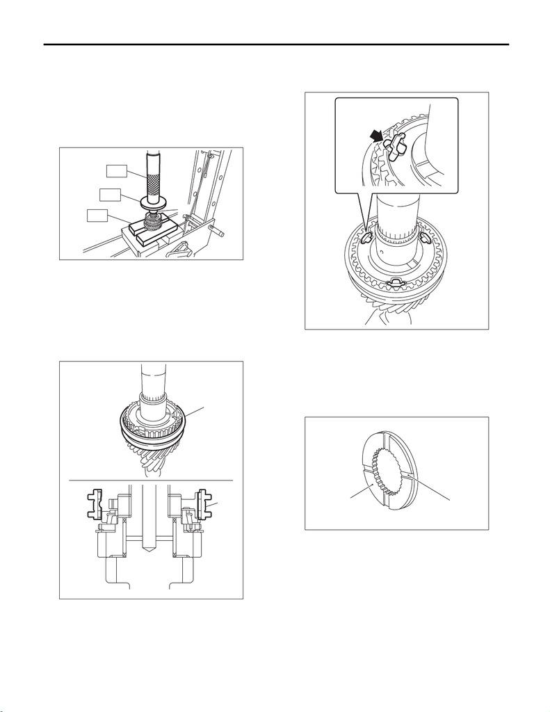

6MT(TY75)-86

Main Shaft Assembly for Single-Range

MANUAL TRANSMISSION AND DIFFERENTIAL

2) Install the 4th needle bearing race using ST1,

ST2, ST3 and a press.

CAUTION:

Do not apply a load in excess of 10 kN (1 ton, 1.1

US ton, 1.0 Imp ton).

ST1 899714110 REMOVER

ST2 499877000 RACE 4-5 INSTALLER

ST3 398177700 INSTALLER

3) Install the 3rd-4th coupling sleeve.

NOTE:

• Install the 3rd-4th coupling sleeve in the correct

direction.

• Align the alignment marks of 3rd-4th coupling

sleeve and the 3rd-4th synchronizer hub.

4) Install the 3rd-4th shifting insert.

NOTE:

Press in the ball part to install.

5) Install the 4th baulk ring, needle bearing, 4th

drive gear and 4th gear adjusting washer.

NOTE:

• Align the protrusion of the 4th baulk ring into the

groove of the 3rd-4th synchronizer hub.

• Install the 4th gear adjusting washer with the

groove side facing the 4th drive gear.

(A) 4th needle bearing race

(A) 3rd-4th coupling sleeve

MT-02479

ST1

ST3

ST2

(A)

MT-02480

(A)

(A)

(A) Groove

(B) Face this surface to the 4th gear side.

MT-02481

MT-02131

(A)

(B)

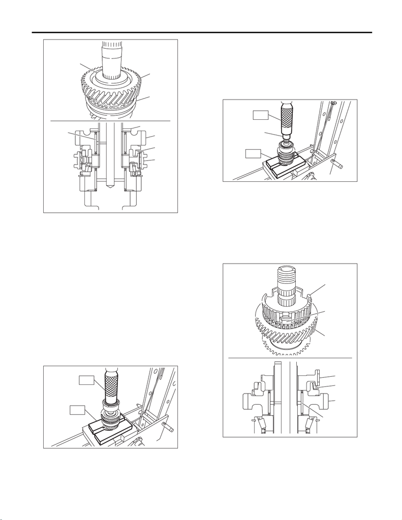

6MT(TY75)-87

Main Shaft Assembly for Single-Range

MANUAL TRANSMISSION AND DIFFERENTIAL

6) Install the double taper roller bearing using ST1,

ST2 and a press.

CAUTION:

Do not apply a load in excess of 10 kN (1 ton, 1.1

US ton, 1.0 Imp ton).

NOTE:

• Use a new double taper roller bearing.

• Install the double taper roller bearing with snap

ring side facing the 5th drive gear side.

ST1 899714110 REMOVER

ST2 499877000 RACE 4-5 INSTALLER

7) Make sure that the double taper roller bearing

turns smoothly.

8) Install the 5th needle bearing race using ST1,

ST2 and press.

CAUTION:

Do not apply a load in excess of 10 kN (1 ton, 1.1

US ton, 1.0 Imp ton).

ST1 899714110 REMOVER

ST2 499877000 RACE 4-5 INSTALLER

9) Install the needle bearing, 5th drive gear, 5th

baulk ring, and 5th-6th synchronizer hub.

NOTE:

• Align the protrusion part of the 5th baulk ring with

the groove of the 5th-6th synchronizer hub.

• Install the 5th-6th synchronizer hub in the correct

direction.

(A) 3rd-4th coupling sleeve

(B) 4th baulk ring

(C) 4th drive gear

(D) Needle bearing

(E) 4th gear adjusting washer

MT-02482

(E)

(C)

(A)

(B)

(C)

(A)

(E)

(D)

MT-02483

ST2

ST1

(A) 5th needle bearing race

(A) 5th-6th synchronizer hub

(B) 5th baulk ring

(C) 5th drive gear

(D) 5th needle bearing (cage: black)

MT-02484

ST2

ST1

(A)

MT-02485

(A)

(B)

(C)

(D)

(A)

(B)

(C)

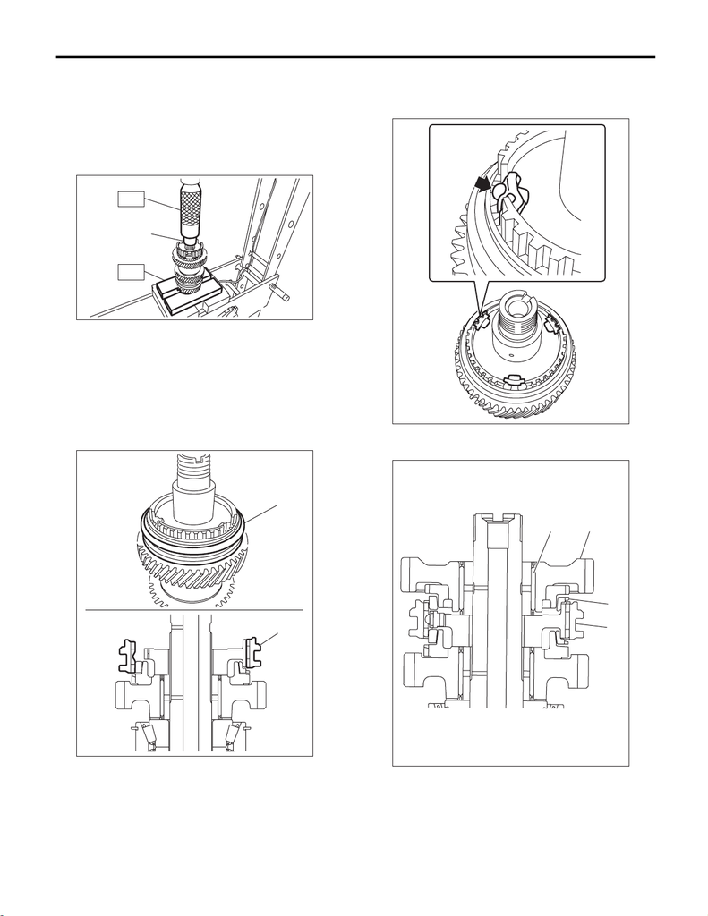

6MT(TY75)-88

Main Shaft Assembly for Single-Range

MANUAL TRANSMISSION AND DIFFERENTIAL

10) Install the 6th needle bearing race using ST1,

ST2 and press.

CAUTION:

Do not apply a load in excess of 10 kN (1 ton, 1.1

US ton, 1.0 Imp ton).

ST1 899714110 REMOVER

ST2 499877000 RACE 4-5 INSTALLER

11) Install the 5th-6th coupling sleeve.

NOTE:

• Install the 5th-6th coupling sleeve in the correct

direction.

• Align the alignment marks of 5th-6th coupling

sleeve and the 5th-6th synchronizer hub.

12) Install the 5th-6th shifting insert.

NOTE:

Press in the ball part to install.

13) Install the 6th baulk ring, 6th drive gear and

needle bearing.

(A) 6th needle bearing race

(A) 5th-6th coupling sleeve

MT-02486

ST2

ST1

(A)

MT-03152

(A)

(A)

(A) 5th-6th coupling sleeve

(B) 6th baulk ring

(C) 6th drive gear

(D) 6th needle bearing (cage: silver)

MT-02488

MT-03153

(D)

(C)

(B)

(A)

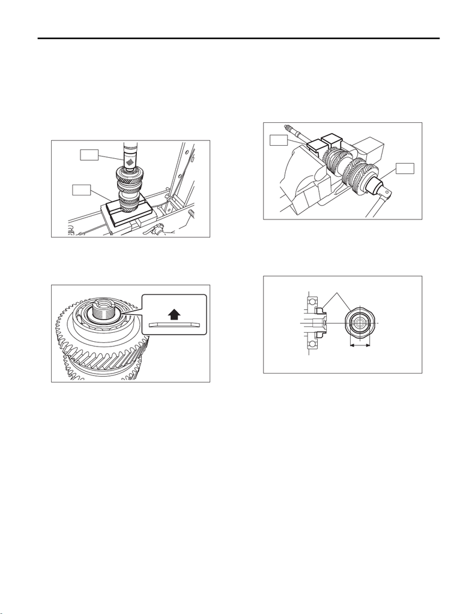

6MT(TY75)-89

Main Shaft Assembly for Single-Range

MANUAL TRANSMISSION AND DIFFERENTIAL

Do not apply a load in excess of 10 kN (1 ton, 1.1

US ton, 1.0 Imp ton).

NOTE:

Install the ball bearing with the side which does not

have lock nut mounting dent facing 6th drive gear.

ST1 899714110 REMOVER

ST2 899754112 PRESS

15) Install the lock washer.

NOTE:

• Use a new lock washer.

• Install the lock washer in the correct direction.

16) Install the lock nut using ST1 and ST2.

NOTE:

Use a new lock nut.

Tightening torque:

160 N·m (16.3 kgf-m, 118.0 ft-lb)

ST1 498937000 TRANSMISSION HOLDER

ST2 499987003 SOCKET WRENCH (35)

17) Crimp the lock nut at two locations so that the

dimension (B) becomes 23.3 mm (0.92 in) or less.

CAUTION:

When crimping the lock nut, be careful not to

crack it.

(A) Lock nut side

MT-02490

ST1

ST2

MT-02491

(A)

(A) Lock nut

(B) Outer dimension after crimping

MT-02473

ST1

ST2

MT-02702

(A)

(B)

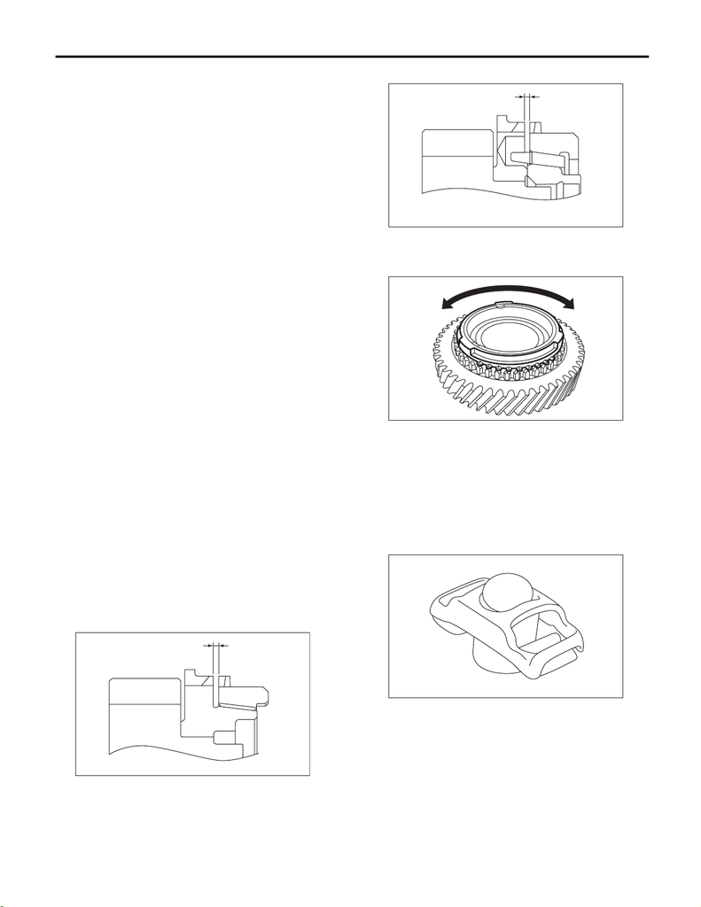

6MT(TY75)-90

Main Shaft Assembly for Single-Range

MANUAL TRANSMISSION AND DIFFERENTIAL

E: INSPECTION

Disassembled parts should be washed with clean-

ing solvent first, then inspected.

1) Bearing

Replace the bearings in the following cases.

• When the bearing balls, outer races and inner

races are broken or rusty.

• When the bearing is worn.

• When the bearings fail to turn smoothly or emit

noise in rotation after gear oil lubrication.

• When bearing has other defects.

2) Bushing (each gear)

Replace the bushing in following cases.

• When the sliding surface is damaged or abnor-

mally worn.

• When the inner wall is abnormally worn.

3) Gear

Replace gears in the following cases.

• Replace the gear with new part if its tooth surfac-

es are broken, damaged or excessively worn.

• Correct or replace if the cone that contacts the

baulk ring is rough or damaged.

• Repair or replace if the inner surface or end face

is damaged.

4) Baulk ring, synchro cone

Replace the baulk ring and synchro cone in the fol-

lowing cases.

• When the inner surface or end face is damaged.

• When the baulk ring inner surface is abnormally

or partially worn down.

• When the contact surface of the baulk ring insert

section is cracked or abnormally worn.

• If the gap between the end faces of the baulk ring

and the gear splined part is excessively small,

check the clearance (A) while pressing the ring

against the cone.

Clearance (A):

0.5 mm (0.020 in) or more

• Single cone

• Double cone

• Apply gear oil to the cone of the gear and while

press-fitting the baulk ring, check there is no rota-

tion in the circumferential direction.

5) Coupling sleeve and synchronizer hub

• Check the slipping condition of the coupling

sleeve.

• Check the splines on the coupling sleeve and

synchronizer hub for wear.

6) Shifting insert

Replace the shifting insert if there is deformation,

excessive wear on the ball section or any defective-

ness.

7) Oil seal

Replace the oil seal if the lip is deformed, hard-

ened, worn or defective in any way.

8) Gearshift mechanism

Repair or replace the gearshift mechanism if ex-

cessively worn, bent or defective in any way.

MT-01673

(A)

MT-01674

(A)

MT-02492

MT-02493

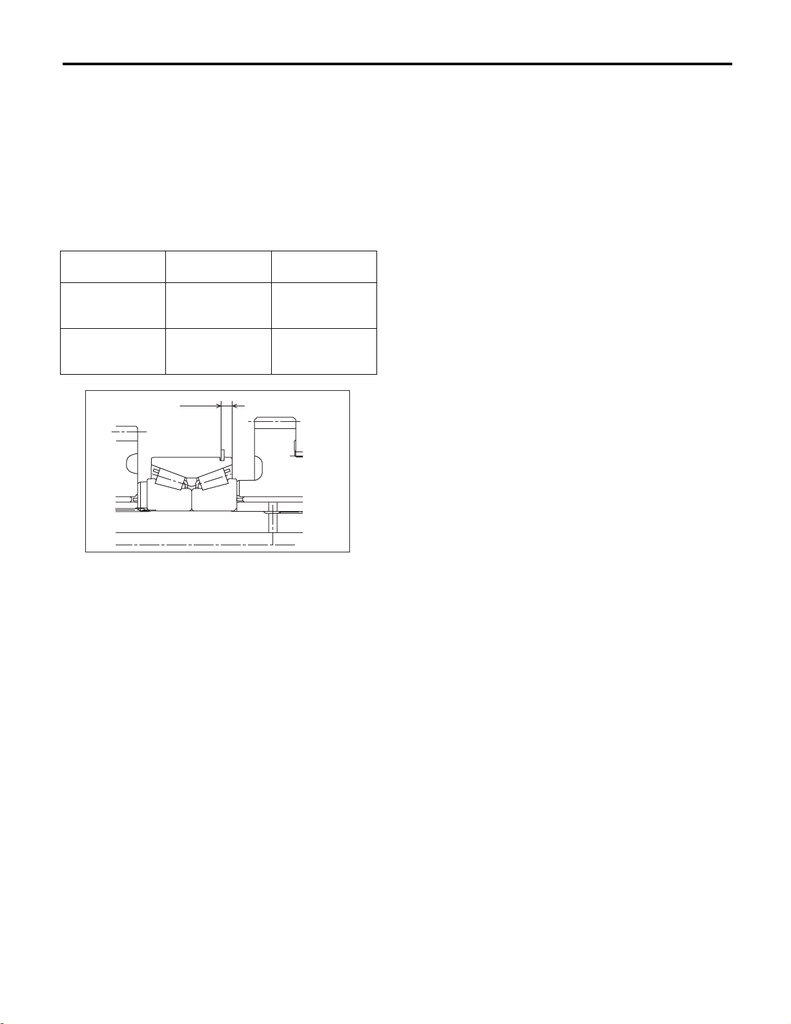

6MT(TY75)-91

Main Shaft Assembly for Single-Range

MANUAL TRANSMISSION AND DIFFERENTIAL

F: ADJUSTMENT

Selection of main shaft rear plate:

Measure the protrusion amount (A) of bearing from

transmission main case surface, and select a suit-

able plate in the following table.

NOTE:

Before measuring, tap the end of main shaft with a

plastic hammer lightly in order to make the clear-

ance zero between the main case surface and

moving flange of bearing.

Dimension (A)

mm (in)

Part No. Mark

4.00 — 4.13

(0.1575 —

0.1626)

32294AA041 1

3.87 — 4.00

(0.1524 —

0.1575)

32294AA051 2

MT-02125

(A)